# Climate Modeling

Charlie Said

2023-10-24

In this project, we examine climate data over time, and how global trends have developed. The purpose of this project is to illustrate how temperature and CO2, the two primary measures of climate change, have changed over time, in what regions they have changed differently, and relative to what other measures such as population or GDP have they changed.

# Introduction

By far the most common metric of climate change cited in contemporary climate literature is carbon (CO2) emissions. According to a data report published by Hannah Ritchie, Max Roser and Pablo Rosado in OurWorldInData, “Carbon dioxide emissions are the primary driver of global climate change. It’s widely recognised that to avoid the worst impacts of climate change, the world needs to urgently reduce emissions.” (Ritchie et. al., 2020). That same report provided a .csv file of CO2 emissions by country over time.

# Overall Trends

## Raw CO2

We first examine global CO2 trends.

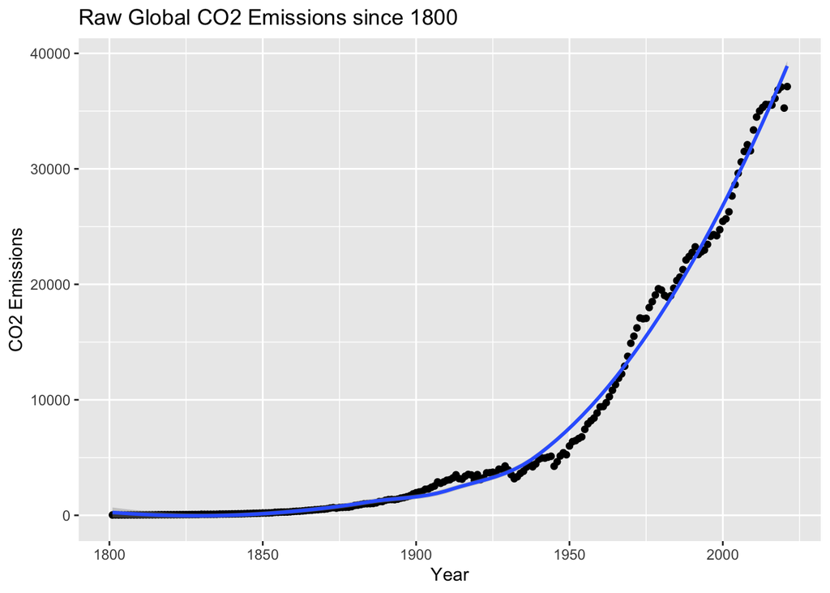

```r
library(tidyverse)
library(readr)
# https://ourworldindata.org/co2-emissions
co2<-read.csv("owid-co2-data.csv")
co2_2<-co2%>%
  filter(country=="World")%>%
  filter(year>1800)
ggplot(co2_2,aes(x=year,y=co2))+
  geom_point()+
  geom_smooth()+
  labs(title="Raw Global CO2 Emissions since 1800",x="Year",y="CO2 Emissions")
```

This shows the exponential growth in CO2 emissions since 1800. However, this is just raw emissions. Population has also grown dramatically since 1800. For that reason, we should look at CO2 emissions per capita.

## CO2 per Capita

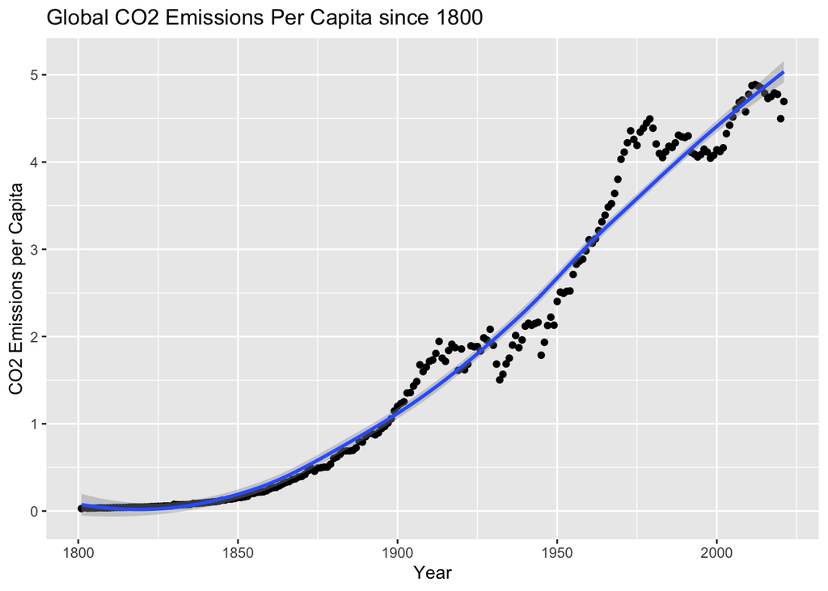

```r
ggplot(co2_2,aes(x=year,y=co2_per_capita))+
  geom_point()+
  geom_smooth()+
  labs(title="Global CO2 Emissions Per Capita since 1800",x="Year",y="CO2 Emissions per Capita")
```

Clearly, emissions per capita have also grown, although their growth has been more linear than exponential since 1900.

## CO2 per GDP

A third metric worth considering is emissions per GDP, since most CO2 emissions are the result of industry and economic growth.

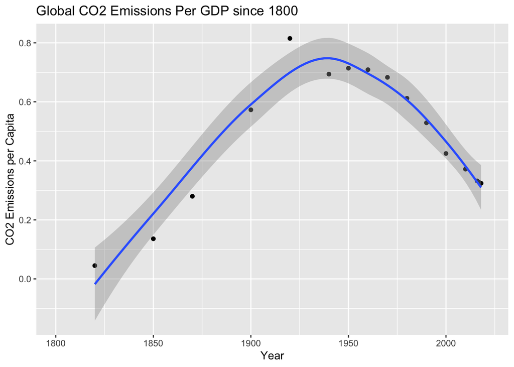

```r
ggplot(co2_2,aes(x=year,y=co2_per_gdp))+
  geom_point()+
  geom_smooth()+
  labs(title="Global CO2 Emissions Per GDP since 1800",x="Year",y="CO2 Emissions per Capita")
```

The data for the world’s GDP is not as complete as we would like, but the plot nonetheless shows a fascinating trend: Since the 1950s, CO2 per GDP has fallen. This suggests that there is not, in fact, a tradeoff between economic growth and environmental responsibility. Logically, it would seem that the more advanced an economy is, the more it can afford to focus on green energy and other climate solutions. That’s just speculation, but it would explain this surprising trend.

But on the topic of environmental responsibility, which country is responsible for damaging the climate the most?

# Assessing Individual Nations

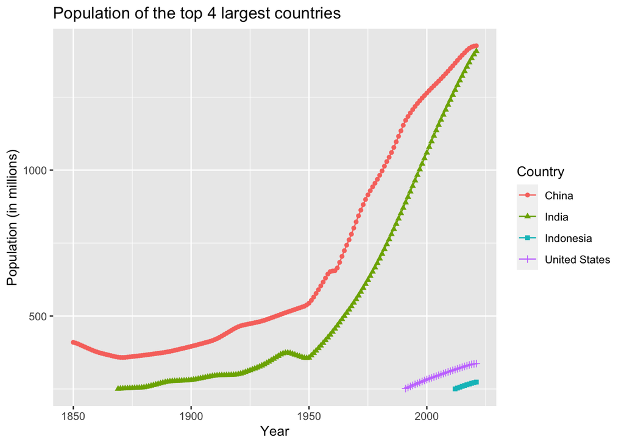

```r
popTrends<-co2%>%
  mutate(population=population/1000000)%>%
  filter(country!="South America" & country!="North America" & country!="Europe" & country!="Asia" & country!="Africa" & country!="World" & country!="Low-income countries" & country!="Lower-middle-income countries" & country!="High-income countries" & country!="Upper-middle-income countries" & country!="European Union (27)")%>%
  filter(population>250)%>%
  select(country,year,population,co2,co2_per_capita,co2_per_gdp)
ggplot(popTrends,aes(y=population,x=year,color=country,shape=country))+
  geom_point()+
  geom_line()+
  labs(title="Population of the top 4 largest countries",x="Year",y="Population (in millions)",color="Country",shape="Country")
```

For the sake of simplicity, we will examine just these four countries.

## Raw CO2

First, we look at raw CO2 emissions:

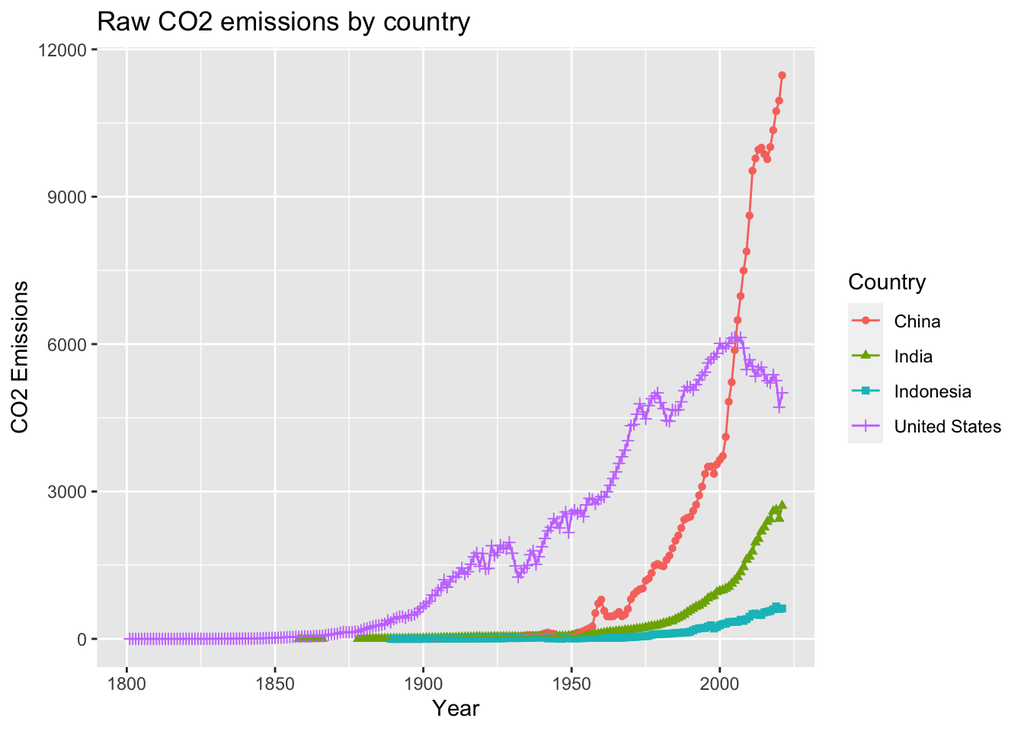

```r
startingYear<-1800

big4<-co2%>%
  filter(country=="United States"|country=="China"|country=="India"|country=="Indonesia")%>%
  filter(year>startingYear)%>%
  select(country,year,population,co2,co2_per_capita,co2_per_gdp)
#CO2 Raw
ggplot(big4,aes(x=year,y=co2,color=country,shape=country))+
  geom_point()+
  geom_line()+
  labs(title="Raw CO2 emissions by country",x="Year",y="CO2 Emissions",color="Country",shape="Country")
```

This shows that while America was the greatest polluter of the 19th and 20th centuries, China has far surpassed America’s emissions, and has achieved an emissions level in just the last 2 decades that is twice America’s all-time high. In that same time, America has reduced its carbon emissions.

It would also be interesting to look at the UK, to see the effects of the industrial revolution there. So we will substitute the UK instead of Indonesia in the above graph.

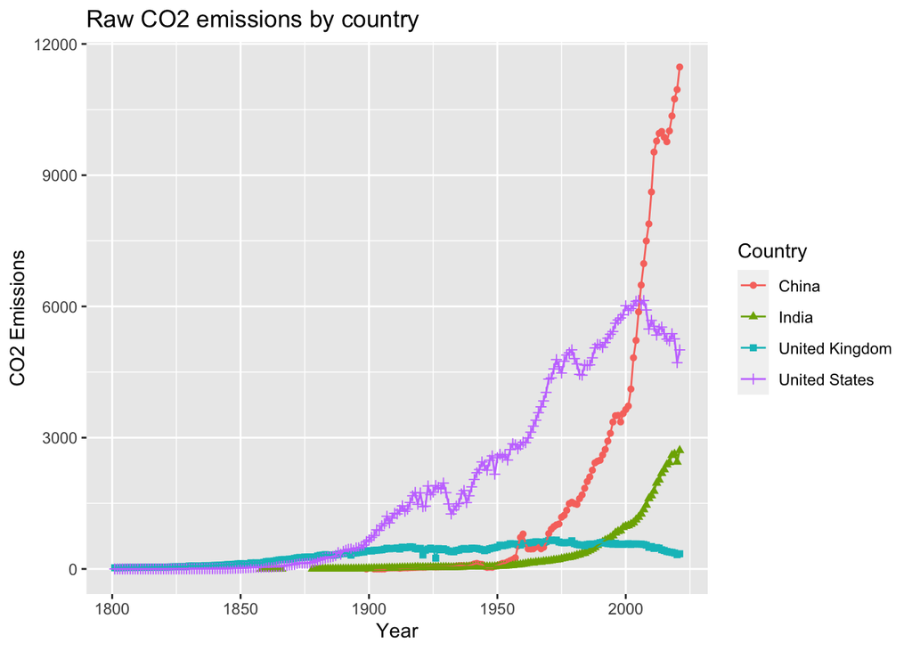

```r
startingYear<-1800

big3PlusUK<-co2%>%
  filter(country=="United States"|country=="China"|country=="India"|country=="United Kingdom")%>%
  filter(year>startingYear)%>%
  select(country,year,population,co2,co2_per_capita,co2_per_gdp)
#CO2 Raw
ggplot(big3PlusUK,aes(x=year,y=co2,color=country,shape=country))+
  geom_point()+
  geom_line()+
  labs(title="Raw CO2 emissions by country",x="Year",y="CO2 Emissions",color="Country",shape="Country")
```

The UK does not register a major spike at all, which suggests that the effects of the industrial revolution there did not significantly contribute to climate change.

## CO2 per capita

However, it’s only fair to examine emissions per capita:

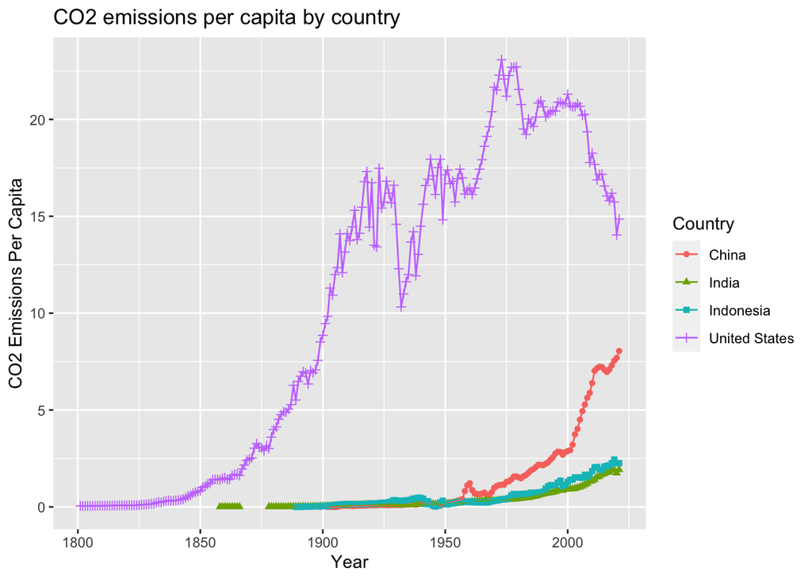

```r
#CO2 Per Capita
ggplot(big4,aes(x=year,y=co2_per_capita,color=country,shape=country))+
  geom_point()+
  geom_line()+
  labs(title="CO2 emissions per capita by country",x="Year",y="CO2 Emissions Per Capita",,color="Country",shape="Country")
```

Here, the story is not so great for America. The United States contributes the vast majority of emissions per capita, meaning that our citizens are worse for the environment than the citizens of the other three countries here examined. However, there is good news: Since 1975, American emissions per capita has dropped. That was around the same time that China’s emissions per capita began to rise, and if trends continue, China could pass America as the worst CO2 emitter on a per-capita basis.

## CO2 per GDP

Lastly, to keep our analysis consistent with the prior plots, we should examine emissions per GDP.

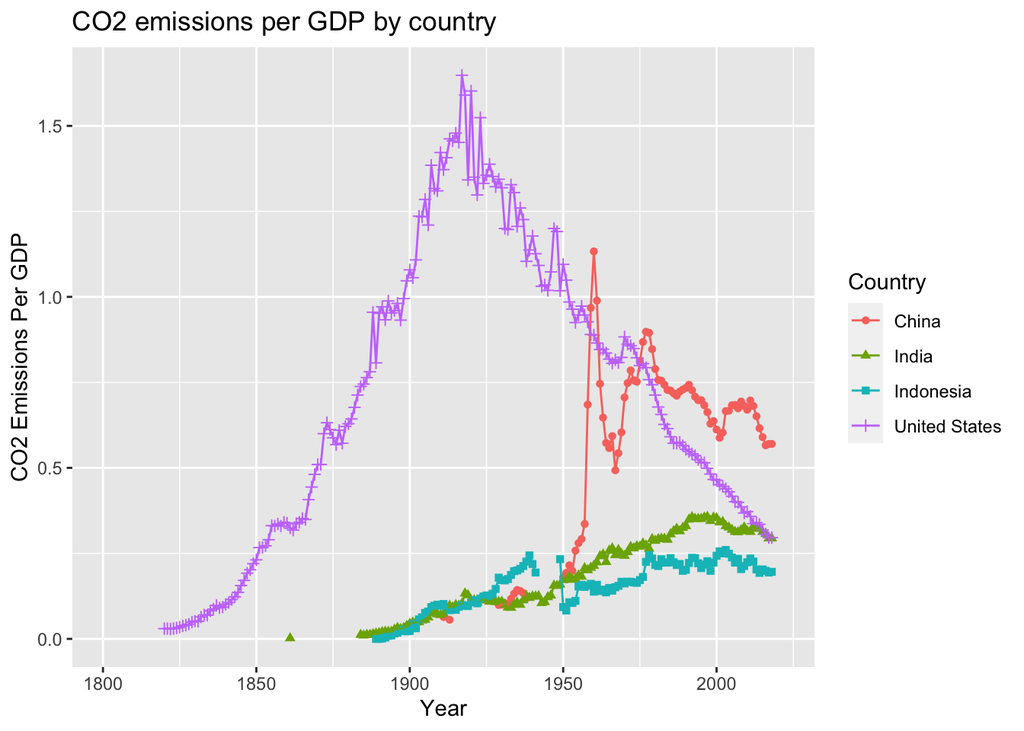

```r
ggplot(big4,aes(x=year,y=co2_per_gdp,color=country,shape=country))+
  geom_point()+
  geom_line()+
  labs(title="CO2 emissions per GDP by country",x="Year",y="CO2 Emissions Per GDP",,color="Country",shape="Country")
```

This is by far the most complex plot we’ve examined yet, but is very interesting. It shows that both America and China rapidly increased their emissions per GDP, America peaking around the 1920s, and China in the 1950s and 60s. Since then, both have declined, demonstrating that economic growth can happen without necessarily harming the environment. India is on track to overtake America in emissions per GDP, China already has, and if America’s decline in emissions per GDP continues, Indonesia will as well.

# Conclusion

Climate policy is an area that demands genuine negotiation between these nations, so understanding who bears what responsibility for emissions is critical. However, there are many different metrics that could be examined, so conclusive statements of blame are impossible and unhelpful. The data should be examined on a policy-specific basis, to design reforms that hold the greatest polluters to account and reduce net global emissions for all people.

# Bibliography

Ritchie, H., Roser, M., & Rosado, P. (2020). CO₂ and Greenhouse Gas Emissions. Our World in Data. https://ourworldindata.org/co2-emissions